# Risk Factor Analysis

## Outcome Variable

**Outcome Variable:** whz

## Predictor Variables

**Intervention Variable:** impfloor

**Adjustment Set:**

- arm
- sex
- W_mage
- meducyrs
- feducyrs
- hhwealth_quart
- hfoodsec
- W_mhtcm
- W_nrooms
- W_nchldlt5
- W_parity
- impsan
- safeh20
- delta_W_mage
- delta_meducyrs
- delta_feducyrs
- delta_hhwealth_quart
- delta_hfoodsec
- delta_W_mhtcm
- delta_W_nrooms
- delta_W_nchldlt5
- delta_W_parity
- delta_impsan
- delta_safeh20

## Stratifying Variables

The analysis was stratified on these variable(s):

- agecat
- studyid
- country

## Data Summary

| agecat | studyid | country | impfloor | n_cell | n |
| --- | --- | --- | --- | --- | --- |
| Birth | ki0047075b-MAL-ED | BANGLADESH | 1 | 205 | 222 |
| Birth | ki0047075b-MAL-ED | BANGLADESH | 0 | 17 | 222 |
| Birth | ki0047075b-MAL-ED | BRAZIL | 1 | 165 | 167 |
| Birth | ki0047075b-MAL-ED | BRAZIL | 0 | 2 | 167 |
| Birth | ki0047075b-MAL-ED | INDIA | 1 | 178 | 188 |
| Birth | ki0047075b-MAL-ED | INDIA | 0 | 10 | 188 |
| Birth | ki0047075b-MAL-ED | NEPAL | 1 | 64 | 159 |
| Birth | ki0047075b-MAL-ED | NEPAL | 0 | 95 | 159 |
| Birth | ki0047075b-MAL-ED | PERU | 1 | 54 | 252 |
| Birth | ki0047075b-MAL-ED | PERU | 0 | 198 | 252 |
| Birth | ki0047075b-MAL-ED | SOUTH AFRICA | 1 | 196 | 216 |
| Birth | ki0047075b-MAL-ED | SOUTH AFRICA | 0 | 20 | 216 |
| Birth | ki0047075b-MAL-ED | TANZANIA, UNITED REPUBLIC OF | 1 | 7 | 113 |
| Birth | ki0047075b-MAL-ED | TANZANIA, UNITED REPUBLIC OF | 0 | 106 | 113 |
| Birth | ki1000108-CMC-V-BCS-2002 | INDIA | 1 | 71 | 71 |
| Birth | ki1000108-CMC-V-BCS-2002 | INDIA | 0 | 0 | 71 |
| Birth | ki1000108-IRC | INDIA | 1 | 253 | 253 |
| Birth | ki1000108-IRC | INDIA | 0 | 0 | 253 |
| Birth | ki1017093-NIH-Birth | BANGLADESH | 1 | 24 | 28 |
| Birth | ki1017093-NIH-Birth | BANGLADESH | 0 | 4 | 28 |
| Birth | ki1017093c-NIH-Crypto | BANGLADESH | 1 | 18 | 23 |
| Birth | ki1017093c-NIH-Crypto | BANGLADESH | 0 | 5 | 23 |
| Birth | ki1114097-CONTENT | PERU | 1 | 2 | 2 |
| Birth | ki1114097-CONTENT | PERU | 0 | 0 | 2 |
| Birth | kiGH5241-JiVitA-3 | BANGLADESH | 1 | 925 | 15666 |
| Birth | kiGH5241-JiVitA-3 | BANGLADESH | 0 | 14741 | 15666 |
| Birth | kiGH5241-JiVitA-4 | BANGLADESH | 1 | 58 | 683 |
| Birth | kiGH5241-JiVitA-4 | BANGLADESH | 0 | 625 | 683 |
| 6 months | ki0047075b-MAL-ED | BANGLADESH | 1 | 221 | 240 |
| 6 months | ki0047075b-MAL-ED | BANGLADESH | 0 | 19 | 240 |

[output cut: 62 more lines]

The following strata were considered:

- agecat: 24 months, studyid: ki0047075b-MAL-ED, country: BANGLADESH
- agecat: 24 months, studyid: ki0047075b-MAL-ED, country: BRAZIL
- agecat: 24 months, studyid: ki0047075b-MAL-ED, country: INDIA
- agecat: 24 months, studyid: ki0047075b-MAL-ED, country: NEPAL
- agecat: 24 months, studyid: ki0047075b-MAL-ED, country: PERU
- agecat: 24 months, studyid: ki0047075b-MAL-ED, country: SOUTH AFRICA
- agecat: 24 months, studyid: ki0047075b-MAL-ED, country: TANZANIA, UNITED REPUBLIC OF
- agecat: 24 months, studyid: ki1000108-CMC-V-BCS-2002, country: INDIA
- agecat: 24 months, studyid: ki1000108-IRC, country: INDIA
- agecat: 24 months, studyid: ki1017093-NIH-Birth, country: BANGLADESH
- agecat: 24 months, studyid: ki1017093b-PROVIDE, country: BANGLADESH
- agecat: 24 months, studyid: ki1017093c-NIH-Crypto, country: BANGLADESH
- agecat: 24 months, studyid: ki1113344-GMS-Nepal, country: NEPAL
- agecat: 24 months, studyid: ki1114097-CONTENT, country: PERU
- agecat: 24 months, studyid: kiGH5241-JiVitA-3, country: BANGLADESH
- agecat: 24 months, studyid: kiGH5241-JiVitA-4, country: BANGLADESH
- agecat: 6 months, studyid: ki0047075b-MAL-ED, country: BANGLADESH
- agecat: 6 months, studyid: ki0047075b-MAL-ED, country: BRAZIL
- agecat: 6 months, studyid: ki0047075b-MAL-ED, country: INDIA
- agecat: 6 months, studyid: ki0047075b-MAL-ED, country: NEPAL
- agecat: 6 months, studyid: ki0047075b-MAL-ED, country: PERU
- agecat: 6 months, studyid: ki0047075b-MAL-ED, country: SOUTH AFRICA
- agecat: 6 months, studyid: ki0047075b-MAL-ED, country: TANZANIA, UNITED REPUBLIC OF
- agecat: 6 months, studyid: ki1000108-CMC-V-BCS-2002, country: INDIA
- agecat: 6 months, studyid: ki1000108-IRC, country: INDIA
- agecat: 6 months, studyid: ki1017093-NIH-Birth, country: BANGLADESH
- agecat: 6 months, studyid: ki1017093b-PROVIDE, country: BANGLADESH
- agecat: 6 months, studyid: ki1017093c-NIH-Crypto, country: BANGLADESH
- agecat: 6 months, studyid: ki1113344-GMS-Nepal, country: NEPAL
- agecat: 6 months, studyid: ki1114097-CONTENT, country: PERU
- agecat: 6 months, studyid: kiGH5241-JiVitA-3, country: BANGLADESH
- agecat: 6 months, studyid: kiGH5241-JiVitA-4, country: BANGLADESH
- agecat: Birth, studyid: ki0047075b-MAL-ED, country: BANGLADESH
- agecat: Birth, studyid: ki0047075b-MAL-ED, country: BRAZIL
- agecat: Birth, studyid: ki0047075b-MAL-ED, country: INDIA
- agecat: Birth, studyid: ki0047075b-MAL-ED, country: NEPAL
- agecat: Birth, studyid: ki0047075b-MAL-ED, country: PERU
- agecat: Birth, studyid: ki0047075b-MAL-ED, country: SOUTH AFRICA
- agecat: Birth, studyid: ki0047075b-MAL-ED, country: TANZANIA, UNITED REPUBLIC OF
- agecat: Birth, studyid: ki1000108-CMC-V-BCS-2002, country: INDIA
- agecat: Birth, studyid: ki1000108-IRC, country: INDIA
- agecat: Birth, studyid: ki1017093-NIH-Birth, country: BANGLADESH
- agecat: Birth, studyid: ki1017093c-NIH-Crypto, country: BANGLADESH
- agecat: Birth, studyid: ki1114097-CONTENT, country: PERU
- agecat: Birth, studyid: kiGH5241-JiVitA-3, country: BANGLADESH
- agecat: Birth, studyid: kiGH5241-JiVitA-4, country: BANGLADESH

### Dropped Strata

Some strata were dropped due to rare outcomes:

- agecat: Birth, studyid: ki0047075b-MAL-ED, country: BRAZIL
- agecat: Birth, studyid: ki1000108-CMC-V-BCS-2002, country: INDIA
- agecat: Birth, studyid: ki1000108-IRC, country: INDIA
- agecat: Birth, studyid: ki1017093-NIH-Birth, country: BANGLADESH
- agecat: Birth, studyid: ki1114097-CONTENT, country: PERU
- agecat: 6 months, studyid: ki0047075b-MAL-ED, country: BRAZIL
- agecat: 6 months, studyid: ki1000108-CMC-V-BCS-2002, country: INDIA
- agecat: 6 months, studyid: ki1000108-IRC, country: INDIA
- agecat: 24 months, studyid: ki0047075b-MAL-ED, country: BRAZIL
- agecat: 24 months, studyid: ki1000108-CMC-V-BCS-2002, country: INDIA
- agecat: 24 months, studyid: ki1000108-IRC, country: INDIA

## Methods Detail

We’re interested in the causal parameters $E[Y_a]$ for all values of $a \in \mathcal{A}$. These parameters represent the mean outcome if, possibly contrary to fact, we intervened to set all units to have $A=a$. Under the randomization and positivity assumptions, these are identified by the statistical parameters $\psi_a=E_W[E_{Y|A,W}(Y|A=a,W)]$. In addition, we’re interested in the mean of $Y$, $E[Y]$ under no intervention (the observed mean). We will estimate these parameters by using SuperLearner to fit the relevant likelihood factors – $E_{Y|A,W}(Y|A=a,W)$ and $p(A=a|W)$, and then updating our likelihood fit using a joint TMLE.

For unadjusted analyses ($W=\{\}$), initial likelihoods were estimated using Lrnr_glm to estimate the simple $E(Y|A)$ and Lrnr_mean to estimate $p(A)$. For adjusted analyses, a small library containing Lrnr_glmnet, Lrnr_xgboost, and Lrnr_mean was used.

Having estimated these parameters, we will then use the delta method to estimate relative risks and attributable risks relative to a prespecified baseline level of $A$.

# Results Detail

## Results Plots

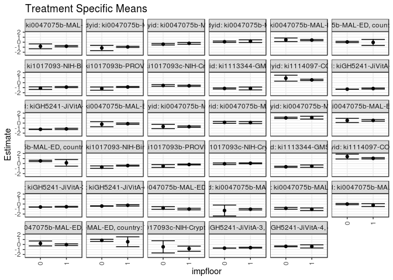

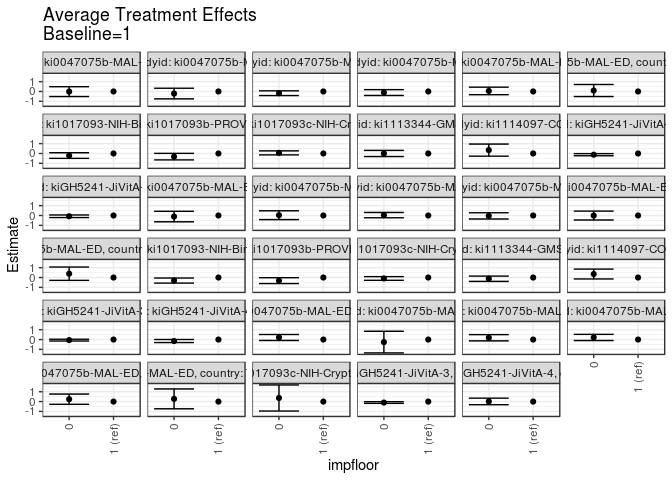

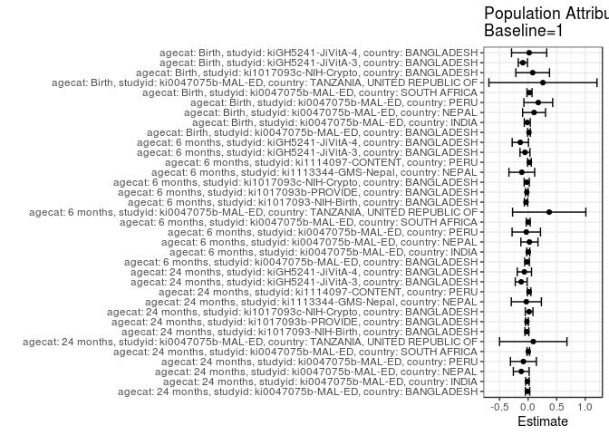

## Results Table

### Parameter: TSM

| agecat | studyid | country | intervention_level | baseline_level | estimate | ci_lower | ci_upper |
| --- | --- | --- | --- | --- | --- | --- | --- |
| Birth | ki0047075b-MAL-ED | BANGLADESH | 1 | NA | -1.0051834 | -1.1558990 | -0.8544679 |
| Birth | ki0047075b-MAL-ED | BANGLADESH | 0 | NA | -0.7937676 | -1.0569195 | -0.5306157 |
| Birth | ki0047075b-MAL-ED | INDIA | 1 | NA | -1.0383874 | -1.1790539 | -0.8977209 |
| Birth | ki0047075b-MAL-ED | INDIA | 0 | NA | -1.2968587 | -2.3884460 | -0.2052714 |
| Birth | ki0047075b-MAL-ED | NEPAL | 1 | NA | -1.0401907 | -1.3009015 | -0.7794799 |
| Birth | ki0047075b-MAL-ED | NEPAL | 0 | NA | -0.8577782 | -1.0364522 | -0.6791042 |
| Birth | ki0047075b-MAL-ED | PERU | 1 | NA | -0.2166302 | -0.5028778 | 0.0696173 |
| Birth | ki0047075b-MAL-ED | PERU | 0 | NA | -0.0015468 | -0.1262567 | 0.1231630 |
| Birth | ki0047075b-MAL-ED | SOUTH AFRICA | 1 | NA | -0.0310576 | -0.1968340 | 0.1347188 |
| Birth | ki0047075b-MAL-ED | SOUTH AFRICA | 0 | NA | 0.2115057 | -0.2804871 | 0.7034985 |
| Birth | ki0047075b-MAL-ED | TANZANIA, UNITED REPUBLIC OF | 1 | NA | 0.5485714 | -0.4383071 | 1.5354500 |
| Birth | ki0047075b-MAL-ED | TANZANIA, UNITED REPUBLIC OF | 0 | NA | 0.8251887 | 0.6170513 | 1.0333260 |
| Birth | ki1017093c-NIH-Crypto | BANGLADESH | 1 | NA | -0.8305556 | -1.3428871 | -0.3182240 |
| Birth | ki1017093c-NIH-Crypto | BANGLADESH | 0 | NA | -0.4640000 | -1.6852927 | 0.7572927 |
| Birth | kiGH5241-JiVitA-3 | BANGLADESH | 1 | NA | -0.6306620 | -0.7137549 | -0.5475690 |
| Birth | kiGH5241-JiVitA-3 | BANGLADESH | 0 | NA | -0.7284893 | -0.7491219 | -0.7078567 |
| Birth | kiGH5241-JiVitA-4 | BANGLADESH | 1 | NA | -0.3860432 | -0.7044931 | -0.0675933 |
| Birth | kiGH5241-JiVitA-4 | BANGLADESH | 0 | NA | -0.3713613 | -0.4561963 | -0.2865263 |
| 6 months | ki0047075b-MAL-ED | BANGLADESH | 1 | NA | -0.1165578 | -0.2506304 | 0.0175148 |
| 6 months | ki0047075b-MAL-ED | BANGLADESH | 0 | NA | -0.2231194 | -0.7366325 | 0.2903937 |
| 6 months | ki0047075b-MAL-ED | INDIA | 1 | NA | -0.7075263 | -0.8390446 | -0.5760081 |
| 6 months | ki0047075b-MAL-ED | INDIA | 0 | NA | -0.6757533 | -1.1020074 | -0.2494992 |
| 6 months | ki0047075b-MAL-ED | NEPAL | 1 | NA | 0.1056231 | -0.0912869 | 0.3025330 |
| 6 months | ki0047075b-MAL-ED | NEPAL | 0 | NA | 0.1452084 | -0.0393657 | 0.3297825 |
| 6 months | ki0047075b-MAL-ED | PERU | 1 | NA | 1.0849755 | 0.7997739 | 1.3701772 |
| 6 months | ki0047075b-MAL-ED | PERU | 0 | NA | 1.0469854 | 0.9102820 | 1.1836888 |
| 6 months | ki0047075b-MAL-ED | SOUTH AFRICA | 1 | NA | 0.5391847 | 0.3755117 | 0.7028578 |
| 6 months | ki0047075b-MAL-ED | SOUTH AFRICA | 0 | NA | 0.5350967 | 0.1131547 | 0.9570387 |
| 6 months | ki0047075b-MAL-ED | TANZANIA, UNITED REPUBLIC OF | 1 | NA | 0.1469507 | -0.5149357 | 0.8088372 |
| 6 months | ki0047075b-MAL-ED | TANZANIA, UNITED REPUBLIC OF | 0 | NA | 0.5360428 | 0.4024176 | 0.6696680 |
| 6 months | ki1017093-NIH-Birth | BANGLADESH | 1 | NA | -0.3992270 | -0.4944989 | -0.3039551 |
| 6 months | ki1017093-NIH-Birth | BANGLADESH | 0 | NA | -0.7073337 | -0.9478473 | -0.4668200 |
| 6 months | ki1017093b-PROVIDE | BANGLADESH | 1 | NA | -0.1848617 | -0.2728390 | -0.0968844 |
| 6 months | ki1017093b-PROVIDE | BANGLADESH | 0 | NA | -0.5013072 | -0.7859796 | -0.2166348 |
| 6 months | ki1017093c-NIH-Crypto | BANGLADESH | 1 | NA | 0.0546111 | -0.0370630 | 0.1462853 |
| 6 months | ki1017093c-NIH-Crypto | BANGLADESH | 0 | NA | -0.0388387 | -0.2009252 | 0.1232479 |
| 6 months | ki1113344-GMS-Nepal | NEPAL | 1 | NA | -0.5159896 | -0.7632569 | -0.2687224 |
| 6 months | ki1113344-GMS-Nepal | NEPAL | 0 | NA | -0.6393905 | -0.7470122 | -0.5317688 |
| 6 months | ki1114097-CONTENT | PERU | 1 | NA | 1.0458221 | 0.9249562 | 1.1666880 |
| 6 months | ki1114097-CONTENT | PERU | 0 | NA | 1.4010516 | 0.9140701 | 1.8880331 |
| 6 months | kiGH5241-JiVitA-3 | BANGLADESH | 1 | NA | -0.5374533 | -0.6256843 | -0.4492223 |
| 6 months | kiGH5241-JiVitA-3 | BANGLADESH | 0 | NA | -0.5942503 | -0.6153208 | -0.5731799 |
| 6 months | kiGH5241-JiVitA-4 | BANGLADESH | 1 | NA | -0.2535352 | -0.3997292 | -0.1073412 |
| 6 months | kiGH5241-JiVitA-4 | BANGLADESH | 0 | NA | -0.4041349 | -0.4493609 | -0.3589089 |
| 24 months | ki0047075b-MAL-ED | BANGLADESH | 1 | NA | -0.8113197 | -0.9378248 | -0.6848146 |
| 24 months | ki0047075b-MAL-ED | BANGLADESH | 0 | NA | -0.8262523 | -1.3093011 | -0.3432035 |
| 24 months | ki0047075b-MAL-ED | INDIA | 1 | NA | -0.9400782 | -1.0601300 | -0.8200264 |
| 24 months | ki0047075b-MAL-ED | INDIA | 0 | NA | -1.1542029 | -1.6802049 | -0.6282009 |
| 24 months | ki0047075b-MAL-ED | NEPAL | 1 | NA | -0.2283348 | -0.4096920 | -0.0469777 |
| 24 months | ki0047075b-MAL-ED | NEPAL | 0 | NA | -0.4061995 | -0.5607019 | -0.2516972 |
| 24 months | ki0047075b-MAL-ED | PERU | 1 | NA | 0.2025942 | -0.0612799 | 0.4664684 |
| 24 months | ki0047075b-MAL-ED | PERU | 0 | NA | 0.0925628 | -0.0418162 | 0.2269417 |
| 24 months | ki0047075b-MAL-ED | SOUTH AFRICA | 1 | NA | 0.4234910 | 0.2963724 | 0.5506097 |
| 24 months | ki0047075b-MAL-ED | SOUTH AFRICA | 0 | NA | 0.4766217 | 0.1162626 | 0.8369809 |
| 24 months | ki0047075b-MAL-ED | TANZANIA, UNITED REPUBLIC OF | 1 | NA | -0.0466696 | -0.6440728 | 0.5507335 |
| 24 months | ki0047075b-MAL-ED | TANZANIA, UNITED REPUBLIC OF | 0 | NA | 0.0478736 | -0.0812886 | 0.1770358 |
| 24 months | ki1017093-NIH-Birth | BANGLADESH | 1 | NA | -0.8888565 | -0.9941565 | -0.7835565 |
| 24 months | ki1017093-NIH-Birth | BANGLADESH | 0 | NA | -1.0983755 | -1.3628068 | -0.8339441 |
| 24 months | ki1017093b-PROVIDE | BANGLADESH | 1 | NA | -0.8664936 | -0.9524489 | -0.7805382 |
| 24 months | ki1017093b-PROVIDE | BANGLADESH | 0 | NA | -1.1868701 | -1.5062213 | -0.8675188 |
| 24 months | ki1017093c-NIH-Crypto | BANGLADESH | 1 | NA | -0.6275027 | -0.7442358 | -0.5107696 |
| 24 months | ki1017093c-NIH-Crypto | BANGLADESH | 0 | NA | -0.5668035 | -0.7360535 | -0.3975534 |
| 24 months | ki1113344-GMS-Nepal | NEPAL | 1 | NA | -1.1601806 | -1.4469875 | -0.8733737 |
| 24 months | ki1113344-GMS-Nepal | NEPAL | 0 | NA | -1.1581806 | -1.2729529 | -1.0434083 |
| 24 months | ki1114097-CONTENT | PERU | 1 | NA | 0.5502720 | 0.4083054 | 0.6922387 |
| 24 months | ki1114097-CONTENT | PERU | 0 | NA | 0.8930073 | 0.2958634 | 1.4901513 |
| 24 months | kiGH5241-JiVitA-3 | BANGLADESH | 1 | NA | -1.1754721 | -1.2828523 | -1.0680920 |
| 24 months | kiGH5241-JiVitA-3 | BANGLADESH | 0 | NA | -1.3000799 | -1.3238574 | -1.2763025 |
| 24 months | kiGH5241-JiVitA-4 | BANGLADESH | 1 | NA | -1.1574669 | -1.2869283 | -1.0280055 |
| 24 months | kiGH5241-JiVitA-4 | BANGLADESH | 0 | NA | -1.2345541 | -1.2709609 | -1.1981473 |

### Parameter: E(Y)

| agecat | studyid | country | intervention_level | baseline_level | estimate | ci_lower | ci_upper |
| --- | --- | --- | --- | --- | --- | --- | --- |
| Birth | ki0047075b-MAL-ED | BANGLADESH | NA | NA | -0.9902252 | -1.1311070 | -0.8493435 |
| Birth | ki0047075b-MAL-ED | INDIA | NA | NA | -1.0536702 | -1.1965043 | -0.9108361 |
| Birth | ki0047075b-MAL-ED | NEPAL | NA | NA | -0.9364780 | -1.0810831 | -0.7918728 |
| Birth | ki0047075b-MAL-ED | PERU | NA | NA | -0.0384921 | -0.1542085 | 0.0772244 |
| Birth | ki0047075b-MAL-ED | SOUTH AFRICA | NA | NA | -0.0073148 | -0.1632037 | 0.1485740 |
| Birth | ki0047075b-MAL-ED | TANZANIA, UNITED REPUBLIC OF | NA | NA | 0.8080531 | 0.6030895 | 1.0130167 |
| Birth | ki1017093c-NIH-Crypto | BANGLADESH | NA | NA | -0.7508696 | -1.2358912 | -0.2658480 |
| Birth | kiGH5241-JiVitA-3 | BANGLADESH | NA | NA | -0.7235197 | -0.7433637 | -0.7036757 |
| Birth | kiGH5241-JiVitA-4 | BANGLADESH | NA | NA | -0.3683163 | -0.4490504 | -0.2875821 |
| 6 months | ki0047075b-MAL-ED | BANGLADESH | NA | NA | -0.1354618 | -0.2647919 | -0.0061317 |
| 6 months | ki0047075b-MAL-ED | INDIA | NA | NA | -0.7056667 | -0.8312524 | -0.5800810 |
| 6 months | ki0047075b-MAL-ED | NEPAL | NA | NA | 0.1286317 | -0.0051407 | 0.2624042 |
| 6 months | ki0047075b-MAL-ED | PERU | NA | NA | 1.0527407 | 0.9299728 | 1.1755087 |
| 6 months | ki0047075b-MAL-ED | SOUTH AFRICA | NA | NA | 0.5403280 | 0.3866002 | 0.6940558 |
| 6 months | ki0047075b-MAL-ED | TANZANIA, UNITED REPUBLIC OF | NA | NA | 0.5162517 | 0.3853881 | 0.6471153 |
| 6 months | ki1017093-NIH-Birth | BANGLADESH | NA | NA | -0.4362094 | -0.5254855 | -0.3469333 |
| 6 months | ki1017093b-PROVIDE | BANGLADESH | NA | NA | -0.2083706 | -0.2927992 | -0.1239419 |
| 6 months | ki1017093c-NIH-Crypto | BANGLADESH | NA | NA | 0.0297622 | -0.0491685 | 0.1086930 |
| 6 months | ki1113344-GMS-Nepal | NEPAL | NA | NA | -0.6267309 | -0.7246812 | -0.5287807 |
| 6 months | ki1114097-CONTENT | PERU | NA | NA | 1.0684318 | 0.9515274 | 1.1853362 |
| 6 months | kiGH5241-JiVitA-3 | BANGLADESH | NA | NA | -0.5926720 | -0.6122891 | -0.5730549 |
| 6 months | kiGH5241-JiVitA-4 | BANGLADESH | NA | NA | -0.3901347 | -0.4273932 | -0.3528762 |
| 24 months | ki0047075b-MAL-ED | BANGLADESH | NA | NA | -0.8208255 | -0.9429246 | -0.6987264 |
| 24 months | ki0047075b-MAL-ED | INDIA | NA | NA | -0.9522907 | -1.0676596 | -0.8369219 |
| 24 months | ki0047075b-MAL-ED | NEPAL | NA | NA | -0.3487330 | -0.4631704 | -0.2342957 |
| 24 months | ki0047075b-MAL-ED | PERU | NA | NA | 0.1199005 | -0.0000331 | 0.2398341 |
| 24 months | ki0047075b-MAL-ED | SOUTH AFRICA | NA | NA | 0.4267017 | 0.3074751 | 0.5459283 |
| 24 months | ki0047075b-MAL-ED | TANZANIA, UNITED REPUBLIC OF | NA | NA | 0.0429953 | -0.0825155 | 0.1685060 |
| 24 months | ki1017093-NIH-Birth | BANGLADESH | NA | NA | -0.9106710 | -1.0090143 | -0.8123277 |
| 24 months | ki1017093b-PROVIDE | BANGLADESH | NA | NA | -0.8879412 | -0.9708680 | -0.8050144 |
| 24 months | ki1017093c-NIH-Crypto | BANGLADESH | NA | NA | -0.6103502 | -0.7050157 | -0.5156847 |
| 24 months | ki1113344-GMS-Nepal | NEPAL | NA | NA | -1.1914974 | -1.2943015 | -1.0886933 |
| 24 months | ki1114097-CONTENT | PERU | NA | NA | 0.5668293 | 0.4302437 | 0.7034148 |
| 24 months | kiGH5241-JiVitA-3 | BANGLADESH | NA | NA | -1.2970420 | -1.3203145 | -1.2737694 |
| 24 months | kiGH5241-JiVitA-4 | BANGLADESH | NA | NA | -1.2232311 | -1.2550891 | -1.1913732 |

### Parameter: ATE

| agecat | studyid | country | intervention_level | baseline_level | estimate | ci_lower | ci_upper |
| --- | --- | --- | --- | --- | --- | --- | --- |
| Birth | ki0047075b-MAL-ED | BANGLADESH | 1 | 1 | 0.0000000 | 0.0000000 | 0.0000000 |
| Birth | ki0047075b-MAL-ED | BANGLADESH | 0 | 1 | 0.2114158 | -0.0918036 | 0.5146352 |
| Birth | ki0047075b-MAL-ED | INDIA | 1 | 1 | 0.0000000 | 0.0000000 | 0.0000000 |
| Birth | ki0047075b-MAL-ED | INDIA | 0 | 1 | -0.2584713 | -1.3594880 | 0.8425454 |
| Birth | ki0047075b-MAL-ED | NEPAL | 1 | 1 | 0.0000000 | 0.0000000 | 0.0000000 |
| Birth | ki0047075b-MAL-ED | NEPAL | 0 | 1 | 0.1824125 | -0.1340957 | 0.4989207 |
| Birth | ki0047075b-MAL-ED | PERU | 1 | 1 | 0.0000000 | 0.0000000 | 0.0000000 |
| Birth | ki0047075b-MAL-ED | PERU | 0 | 1 | 0.2150834 | -0.0979995 | 0.5281663 |
| Birth | ki0047075b-MAL-ED | SOUTH AFRICA | 1 | 1 | 0.0000000 | 0.0000000 | 0.0000000 |
| Birth | ki0047075b-MAL-ED | SOUTH AFRICA | 0 | 1 | 0.2425633 | -0.2774908 | 0.7626174 |
| Birth | ki0047075b-MAL-ED | TANZANIA, UNITED REPUBLIC OF | 1 | 1 | 0.0000000 | 0.0000000 | 0.0000000 |
| Birth | ki0047075b-MAL-ED | TANZANIA, UNITED REPUBLIC OF | 0 | 1 | 0.2766173 | -0.7319711 | 1.2852056 |
| Birth | ki1017093c-NIH-Crypto | BANGLADESH | 1 | 1 | 0.0000000 | 0.0000000 | 0.0000000 |
| Birth | ki1017093c-NIH-Crypto | BANGLADESH | 0 | 1 | 0.3665556 | -0.9578460 | 1.6909571 |
| Birth | kiGH5241-JiVitA-3 | BANGLADESH | 1 | 1 | 0.0000000 | 0.0000000 | 0.0000000 |
| Birth | kiGH5241-JiVitA-3 | BANGLADESH | 0 | 1 | -0.0978273 | -0.1819524 | -0.0137022 |
| Birth | kiGH5241-JiVitA-4 | BANGLADESH | 1 | 1 | 0.0000000 | 0.0000000 | 0.0000000 |
| Birth | kiGH5241-JiVitA-4 | BANGLADESH | 0 | 1 | 0.0146818 | -0.3170228 | 0.3463865 |
| 6 months | ki0047075b-MAL-ED | BANGLADESH | 1 | 1 | 0.0000000 | 0.0000000 | 0.0000000 |
| 6 months | ki0047075b-MAL-ED | BANGLADESH | 0 | 1 | -0.1065616 | -0.6385806 | 0.4254574 |
| 6 months | ki0047075b-MAL-ED | INDIA | 1 | 1 | 0.0000000 | 0.0000000 | 0.0000000 |
| 6 months | ki0047075b-MAL-ED | INDIA | 0 | 1 | 0.0317731 | -0.4147657 | 0.4783118 |
| 6 months | ki0047075b-MAL-ED | NEPAL | 1 | 1 | 0.0000000 | 0.0000000 | 0.0000000 |
| 6 months | ki0047075b-MAL-ED | NEPAL | 0 | 1 | 0.0395853 | -0.2287881 | 0.3079588 |
| 6 months | ki0047075b-MAL-ED | PERU | 1 | 1 | 0.0000000 | 0.0000000 | 0.0000000 |
| 6 months | ki0047075b-MAL-ED | PERU | 0 | 1 | -0.0379901 | -0.3542079 | 0.2782276 |
| 6 months | ki0047075b-MAL-ED | SOUTH AFRICA | 1 | 1 | 0.0000000 | 0.0000000 | 0.0000000 |
| 6 months | ki0047075b-MAL-ED | SOUTH AFRICA | 0 | 1 | -0.0040880 | -0.4564488 | 0.4482727 |
| 6 months | ki0047075b-MAL-ED | TANZANIA, UNITED REPUBLIC OF | 1 | 1 | 0.0000000 | 0.0000000 | 0.0000000 |
| 6 months | ki0047075b-MAL-ED | TANZANIA, UNITED REPUBLIC OF | 0 | 1 | 0.3890920 | -0.2862700 | 1.0644541 |
| 6 months | ki1017093-NIH-Birth | BANGLADESH | 1 | 1 | 0.0000000 | 0.0000000 | 0.0000000 |
| 6 months | ki1017093-NIH-Birth | BANGLADESH | 0 | 1 | -0.3081067 | -0.5664846 | -0.0497288 |
| 6 months | ki1017093b-PROVIDE | BANGLADESH | 1 | 1 | 0.0000000 | 0.0000000 | 0.0000000 |
| 6 months | ki1017093b-PROVIDE | BANGLADESH | 0 | 1 | -0.3164455 | -0.6140082 | -0.0188828 |
| 6 months | ki1017093c-NIH-Crypto | BANGLADESH | 1 | 1 | 0.0000000 | 0.0000000 | 0.0000000 |
| 6 months | ki1017093c-NIH-Crypto | BANGLADESH | 0 | 1 | -0.0934498 | -0.2797290 | 0.0928294 |
| 6 months | ki1113344-GMS-Nepal | NEPAL | 1 | 1 | 0.0000000 | 0.0000000 | 0.0000000 |
| 6 months | ki1113344-GMS-Nepal | NEPAL | 0 | 1 | -0.1234009 | -0.3933596 | 0.1465579 |
| 6 months | ki1114097-CONTENT | PERU | 1 | 1 | 0.0000000 | 0.0000000 | 0.0000000 |
| 6 months | ki1114097-CONTENT | PERU | 0 | 1 | 0.3552295 | -0.1474424 | 0.8579013 |
| 6 months | kiGH5241-JiVitA-3 | BANGLADESH | 1 | 1 | 0.0000000 | 0.0000000 | 0.0000000 |
| 6 months | kiGH5241-JiVitA-3 | BANGLADESH | 0 | 1 | -0.0567970 | -0.1478720 | 0.0342781 |
| 6 months | kiGH5241-JiVitA-4 | BANGLADESH | 1 | 1 | 0.0000000 | 0.0000000 | 0.0000000 |
| 6 months | kiGH5241-JiVitA-4 | BANGLADESH | 0 | 1 | -0.1505997 | -0.3052946 | 0.0040952 |
| 24 months | ki0047075b-MAL-ED | BANGLADESH | 1 | 1 | 0.0000000 | 0.0000000 | 0.0000000 |
| 24 months | ki0047075b-MAL-ED | BANGLADESH | 0 | 1 | -0.0149326 | -0.5146692 | 0.4848040 |
| 24 months | ki0047075b-MAL-ED | INDIA | 1 | 1 | 0.0000000 | 0.0000000 | 0.0000000 |
| 24 months | ki0047075b-MAL-ED | INDIA | 0 | 1 | -0.2141247 | -0.7535694 | 0.3253199 |
| 24 months | ki0047075b-MAL-ED | NEPAL | 1 | 1 | 0.0000000 | 0.0000000 | 0.0000000 |
| 24 months | ki0047075b-MAL-ED | NEPAL | 0 | 1 | -0.1778647 | -0.4166166 | 0.0608873 |
| 24 months | ki0047075b-MAL-ED | PERU | 1 | 1 | 0.0000000 | 0.0000000 | 0.0000000 |
| 24 months | ki0047075b-MAL-ED | PERU | 0 | 1 | -0.1100315 | -0.4063390 | 0.1862761 |
| 24 months | ki0047075b-MAL-ED | SOUTH AFRICA | 1 | 1 | 0.0000000 | 0.0000000 | 0.0000000 |
| 24 months | ki0047075b-MAL-ED | SOUTH AFRICA | 0 | 1 | 0.0531307 | -0.3296166 | 0.4358780 |
| 24 months | ki0047075b-MAL-ED | TANZANIA, UNITED REPUBLIC OF | 1 | 1 | 0.0000000 | 0.0000000 | 0.0000000 |
| 24 months | ki0047075b-MAL-ED | TANZANIA, UNITED REPUBLIC OF | 0 | 1 | 0.0945432 | -0.5169441 | 0.7060306 |
| 24 months | ki1017093-NIH-Birth | BANGLADESH | 1 | 1 | 0.0000000 | 0.0000000 | 0.0000000 |
| 24 months | ki1017093-NIH-Birth | BANGLADESH | 0 | 1 | -0.2095190 | -0.4944827 | 0.0754448 |
| 24 months | ki1017093b-PROVIDE | BANGLADESH | 1 | 1 | 0.0000000 | 0.0000000 | 0.0000000 |
| 24 months | ki1017093b-PROVIDE | BANGLADESH | 0 | 1 | -0.3203765 | -0.6515987 | 0.0108457 |
| 24 months | ki1017093c-NIH-Crypto | BANGLADESH | 1 | 1 | 0.0000000 | 0.0000000 | 0.0000000 |
| 24 months | ki1017093c-NIH-Crypto | BANGLADESH | 0 | 1 | 0.0606992 | -0.1448943 | 0.2662927 |
| 24 months | ki1113344-GMS-Nepal | NEPAL | 1 | 1 | 0.0000000 | 0.0000000 | 0.0000000 |
| 24 months | ki1113344-GMS-Nepal | NEPAL | 0 | 1 | 0.0020000 | -0.3093521 | 0.3133521 |
| 24 months | ki1114097-CONTENT | PERU | 1 | 1 | 0.0000000 | 0.0000000 | 0.0000000 |
| 24 months | ki1114097-CONTENT | PERU | 0 | 1 | 0.3427353 | -0.2714600 | 0.9569305 |
| 24 months | kiGH5241-JiVitA-3 | BANGLADESH | 1 | 1 | 0.0000000 | 0.0000000 | 0.0000000 |
| 24 months | kiGH5241-JiVitA-3 | BANGLADESH | 0 | 1 | -0.1246078 | -0.2324532 | -0.0167624 |
| 24 months | kiGH5241-JiVitA-4 | BANGLADESH | 1 | 1 | 0.0000000 | 0.0000000 | 0.0000000 |
| 24 months | kiGH5241-JiVitA-4 | BANGLADESH | 0 | 1 | -0.0770872 | -0.2107107 | 0.0565362 |

### Parameter: PAR

| agecat | studyid | country | intervention_level | baseline_level | estimate | ci_lower | ci_upper |
| --- | --- | --- | --- | --- | --- | --- | --- |
| Birth | ki0047075b-MAL-ED | BANGLADESH | 1 | NA | 0.0149582 | -0.0092919 | 0.0392083 |
| Birth | ki0047075b-MAL-ED | INDIA | 1 | NA | -0.0152828 | -0.0680986 | 0.0375329 |
| Birth | ki0047075b-MAL-ED | NEPAL | 1 | NA | 0.1037127 | -0.0966174 | 0.3040428 |
| Birth | ki0047075b-MAL-ED | PERU | 1 | NA | 0.1781382 | -0.0740379 | 0.4303142 |
| Birth | ki0047075b-MAL-ED | SOUTH AFRICA | 1 | NA | 0.0237428 | -0.0209421 | 0.0684276 |
| Birth | ki0047075b-MAL-ED | TANZANIA, UNITED REPUBLIC OF | 1 | NA | 0.2594817 | -0.6867083 | 1.2056717 |
| Birth | ki1017093c-NIH-Crypto | BANGLADESH | 1 | NA | 0.0796860 | -0.2150777 | 0.3744497 |
| Birth | kiGH5241-JiVitA-3 | BANGLADESH | 1 | NA | -0.0928578 | -0.1733564 | -0.0123591 |
| Birth | kiGH5241-JiVitA-4 | BANGLADESH | 1 | NA | 0.0177269 | -0.2905070 | 0.3259609 |
| 6 months | ki0047075b-MAL-ED | BANGLADESH | 1 | NA | -0.0189040 | -0.0599896 | 0.0221816 |
| 6 months | ki0047075b-MAL-ED | INDIA | 1 | NA | 0.0018597 | -0.0259597 | 0.0296791 |
| 6 months | ki0047075b-MAL-ED | NEPAL | 1 | NA | 0.0230086 | -0.1263555 | 0.1723728 |
| 6 months | ki0047075b-MAL-ED | PERU | 1 | NA | -0.0322348 | -0.2808362 | 0.2163666 |
| 6 months | ki0047075b-MAL-ED | SOUTH AFRICA | 1 | NA | 0.0011432 | -0.0334590 | 0.0357454 |
| 6 months | ki0047075b-MAL-ED | TANZANIA, UNITED REPUBLIC OF | 1 | NA | 0.3693010 | -0.2723983 | 1.0110002 |
| 6 months | ki1017093-NIH-Birth | BANGLADESH | 1 | NA | -0.0369824 | -0.0668144 | -0.0071505 |
| 6 months | ki1017093b-PROVIDE | BANGLADESH | 1 | NA | -0.0235089 | -0.0462715 | -0.0007463 |
| 6 months | ki1017093c-NIH-Crypto | BANGLADESH | 1 | NA | -0.0248489 | -0.0701906 | 0.0204928 |
| 6 months | ki1113344-GMS-Nepal | NEPAL | 1 | NA | -0.1107413 | -0.3362115 | 0.1147289 |
| 6 months | ki1114097-CONTENT | PERU | 1 | NA | 0.0226097 | -0.0092764 | 0.0544957 |
| 6 months | kiGH5241-JiVitA-3 | BANGLADESH | 1 | NA | -0.0552186 | -0.1423480 | 0.0319107 |
| 6 months | kiGH5241-JiVitA-4 | BANGLADESH | 1 | NA | -0.1365994 | -0.2791924 | 0.0059935 |
| 24 months | ki0047075b-MAL-ED | BANGLADESH | 1 | NA | -0.0095058 | -0.0478245 | 0.0288129 |
| 24 months | ki0047075b-MAL-ED | INDIA | 1 | NA | -0.0122126 | -0.0429755 | 0.0185504 |
| 24 months | ki0047075b-MAL-ED | NEPAL | 1 | NA | -0.1203982 | -0.2590298 | 0.0182335 |
| 24 months | ki0047075b-MAL-ED | PERU | 1 | NA | -0.0826937 | -0.3098619 | 0.1444744 |
| 24 months | ki0047075b-MAL-ED | SOUTH AFRICA | 1 | NA | 0.0032106 | -0.0202514 | 0.0266727 |
| 24 months | ki0047075b-MAL-ED | TANZANIA, UNITED REPUBLIC OF | 1 | NA | 0.0896649 | -0.5007762 | 0.6801061 |
| 24 months | ki1017093-NIH-Birth | BANGLADESH | 1 | NA | -0.0218145 | -0.0565252 | 0.0128963 |
| 24 months | ki1017093b-PROVIDE | BANGLADESH | 1 | NA | -0.0214476 | -0.0467884 | 0.0038932 |
| 24 months | ki1017093c-NIH-Crypto | BANGLADESH | 1 | NA | 0.0171525 | -0.0497799 | 0.0840848 |
| 24 months | ki1113344-GMS-Nepal | NEPAL | 1 | NA | -0.0313168 | -0.2950063 | 0.2323727 |
| 24 months | ki1114097-CONTENT | PERU | 1 | NA | 0.0165572 | -0.0157472 | 0.0488617 |
| 24 months | kiGH5241-JiVitA-3 | BANGLADESH | 1 | NA | -0.1215698 | -0.2250127 | -0.0181269 |
| 24 months | kiGH5241-JiVitA-4 | BANGLADESH | 1 | NA | -0.0657642 | -0.1906897 | 0.0591613 |